# PW3_LogisticRegression.R

anais

2020-12-08

```r
dataset = read.csv("C:/Users/anais/Documents/Esilv/S7/Machine Learning/TD/TD3/Social_Network_Ads.csv",header=T,na.strings ="?")
```

#### 2. Explore and Describe the dataset (you can use str() and summary() functions, you can calculate and visualize the correlations, show some histograms, scatterplots, pie charts, etc..).

```r
str(dataset)
```

```
## 'data.frame':    400 obs. of  5 variables:
##  $ User.ID        : int  15624510 15810944 15668575 15603246 15804002 15728773 15598044 15694829 15600575 15727311 ...
##  $ Gender         : Factor w/ 2 levels "Female","Male": 2 2 1 1 2 2 1 1 2 1 ...
##  $ Age            : num  19 35 26 27 19 27 27 32 25 35 ...
##  $ EstimatedSalary: num  19000 20000 43000 57000 76000 58000 84000 150000 33000 65000 ...
##  $ Purchased      : int  0 0 0 0 0 0 0 1 0 0 ...
```

```r
#  $ User.ID        : int  15624510 15810944 15668575 15603246 15804002 15728773 15598044 15694829 15600575 15727311 ...
#$ Gender         : Factor w/ 2 levels "Female","Male": 2 2 1 1 2 2 1 1 2 1 ...
#$ Age            : num  19 35 26 27 19 27 27 32 25 35 ...
#$ EstimatedSalary: num  19000 20000 43000 57000 76000 58000 84000 150000 33000 65000 ...
#$ Purchased      : int  0 0 0 0 0 0 0 1 0 0 ...

summary(dataset)
```

```
##     User.ID            Gender         Age        EstimatedSalary
##  Min.   :15566689   Female:204   Min.   :18.00   Min.   : 15000
##  1st Qu.:15626764   Male  :196   1st Qu.:29.75   1st Qu.: 43000
##  Median :15694342                Median :37.00   Median : 70000
##  Mean   :15691540                Mean   :37.66   Mean   : 69743
##  3rd Qu.:15750363                3rd Qu.:46.00   3rd Qu.: 88000
##  Max.   :15815236                Max.   :60.00   Max.   :150000
##    Purchased
##  Min.   :0.0000
##  1st Qu.:0.0000
##  Median :0.0000
##  Mean   :0.3575
##  3rd Qu.:1.0000
##  Max.   :1.0000
```

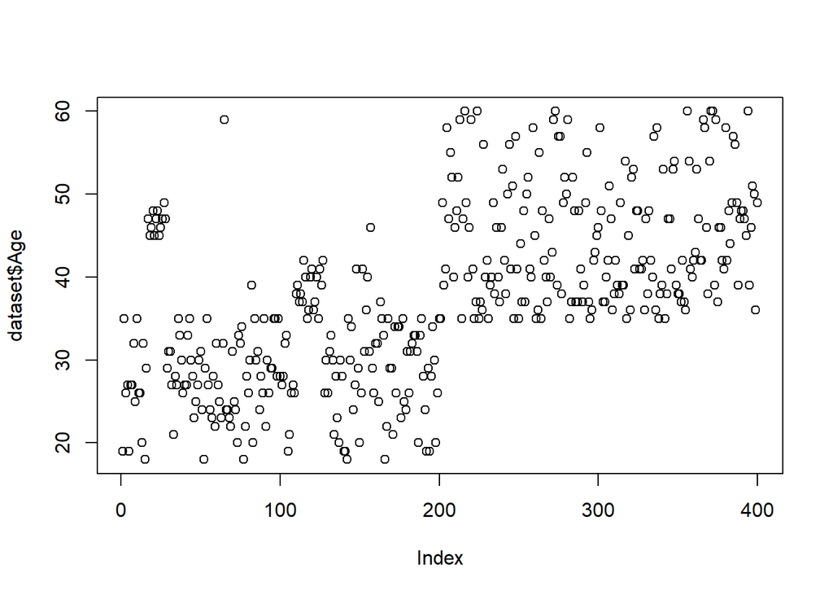

```r
#User.ID            Gender         Age        EstimatedSalary    Purchased
#Min.   :15566689   Female:204   Min.   :18.00   Min.   : 15000   Min.   :0.0000
#1st Qu.:15626764   Male  :196   1st Qu.:29.75   1st Qu.: 43000   1st Qu.:0.0000
#Median :15694342                Median :37.00   Median : 70000   Median :0.0000
#Mean   :15691540                Mean   :37.66   Mean   : 69743   Mean   :0.3575
#3rd Qu.:15750363                3rd Qu.:46.00   3rd Qu.: 88000   3rd Qu.:1.0000
#Max.   :15815236                Max.   :60.00   Max.   :150000   Max.   :1.0000

cor_Age_Purchased = cor(dataset$Age,dataset$Purchased)
#[1] 0.6224542 high positive correlation

plot(dataset$Age)
```

```r
#The subjects are mostly between 20 and 60 years old, and are equally reparted
```

#### 3. Now we are going to split the dataset into training set and test set. Last week we did it manually. From now on we will split it randomly, you can use this code (after undestanding it of course

```r
library(caTools) # install it first in the console
set.seed(123)
# we use the function set.seed() with the same seed number
# to randomly generate the same values, you already know that right?
#and you know why we want to generate the same values, am I wrong?
split = sample.split(dataset$Purchased, SplitRatio = 0.75)
# here we chose the SplitRatio to 75% of the dataset,
# and 25% for the test set.
training_set = subset(dataset, split == TRUE)
# we use subset to split the dataset
test_set = subset(dataset, split == FALSE)
```

#### 4. Scale the input variables in both training set and test set. Do you know what is scaling? Explain it one sentence.

```r
training_set$Age <- scale(training_set$Age)
training_set$EstimatedSalary <- scale(training_set$EstimatedSalary)
#training_set$Purchased <- scale(training_set$Purchased)
test_set$Age <- scale(test_set$Age)
test_set$EstimatedSalary <- scale(test_set$EstimatedSalary)
#test_set$Purchased <- scale(test_set$Purchased)
```